# CPECGM2 Exercises 5

Reister L. Ruedas

Here are some libraries that you may need.

```r
library(ggplot2)
library(plyr)
library(reshape2)
```

We will use the data file `binomial_data.csv`. Let’s load it as the data frame `binomial.data`:

```r
binomial.data <- read.csv(file = 'binomial_data.csv')
```

Each row represents the number of some attribute in a fictional county. There are 10001 rows and 2 columns:

- `population`: the population of the county
- `actual`: the number of observed people with the attribute.

Overall, about `0.002` of the total population in the entire data set has the attribute.

Problem 1:

Confirm that the overall per capita rate is about `0.002`:

```r
# fill in
overall.capita = sum(binomial.data$actual)/ sum(binomial.data$population)
overall.capita
```

```
## [1] 0.002001448
```

Problem 2:

Compute the observed per capita rates, and plot them as a function of the population.

Do the smallest populations have the highest variance in the per capita rates?

```r
# fill in
binomial.data = mutate(binomial.data, observed.capita.rates = actual/population)
head(binomial.data)
```

```
##   population actual observed.capita.rates
## 1        171      0           0.000000000
## 2       5715      9           0.001574803
## 3       4522      8           0.001769129
## 4       8273     27           0.003263629
## 5       1755      3           0.001709402
## 6       8466     18           0.002126152
```

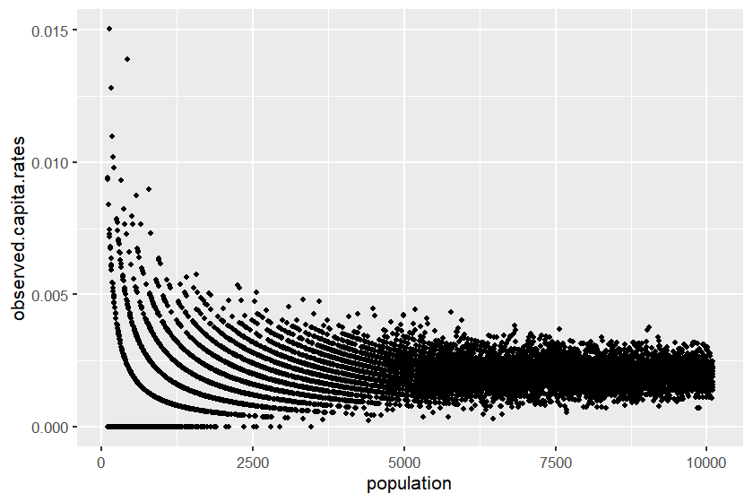

```r
ggplot(data = binomial.data, mapping=aes(x = population, y = observed.capita.rates)) + geom_point(size=1)
```

ANS: Yes, looking at the plot it shows that in the lowest population region it has the highest variance in the per capita rates.

Problem 3:

Consider the null hypothesis that every county is actually a binomial random variable with probability parameter `p= 0.002`.

Compute the expected number of people with the attributes under this null hypothesis. Also compute the standard deviation under the null, and the residual and standardized residuals for each county.

```r
# fill in
county.data = sum(binomial.data$actual)/ sum(binomial.data$population)
# compute the expected and residual values under the null hypothesis:
binomial.data = mutate(binomial.data,
    expected.people = population * county.data,
    st.dev.people = sqrt(expected.people*(1 - county.data)),
    residual = actual - expected.people,
    std.residual = residual / st.dev.people)
head(binomial.data)
```

```
##   population actual observed.capita.rates expected.people st.dev.people
## 1        171      0           0.000000000       0.3422477     0.5844336
## 2       5715      9           0.001574803      11.4382774     3.3786661
## 3       4522      8           0.001769129       9.0505495     3.0054010
## 4       8273     27           0.003263629      16.5579824     4.0650759
## 5       1755      3           0.001709402       3.5125419     1.8723012
## 6       8466     18           0.002126152      16.9442619     4.1122195
##     residual std.residual
## 1 -0.3422477   -0.5856057
## 2 -2.4382774   -0.7216687
## 3 -1.0505495   -0.3495539
## 4 10.4420176    2.5687140
## 5 -0.5125419   -0.2737497
## 6  1.0557381    0.2567319
```

Problem 4:

Add a reference line to the plot in problem 2, denoting for which counties the standardized residual is above 3. Label or title your plot appropriately so that readers will know what the reference line signifies.

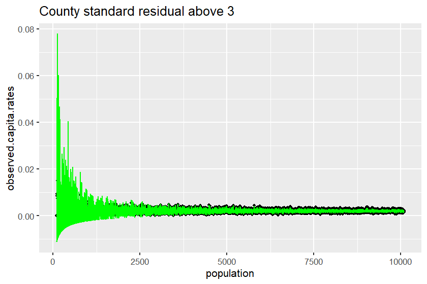

```r
# fill in with comments
ggplot(binomial.data,aes(x = population, y = observed.capita.rates)) +
    geom_point(size=1) +
     geom_line(mapping=aes(y = (expected.people + 3 * std.residual)/population), color='green')  +
    labs(title='County standard residual above 3')
```

Problem 5:

How many counties had a standardized residual exceeding 3? How many would you expect if the null hypothesis was actually correct?

Consider the following two possibilities:

1. every county has about the same risk parameter `p`.
2. some counties have higher risk parameters than others

Which do you think is the better hypothesis for this data set?

```r
# fill in
total.std.residual = sum(binomial.data$std.residual >= 3)
total.std.residual
```

```
## [1] 35
```